# 01 - Análisis Preliminar de Bandas | MicaSense RedEdge P-Dual

Autor/a

Christian Rueda-Ayala

Fecha de publicación

19 de septiembre de 2025

# 1 Introducción

Este documento tiene como objetivo analizar las discrepancias identificadas entre la documentación técnica oficial y los metadatos EXIF de las imágenes obtenidas con cámaras multiespectrales MicaSense RedEdge P-Dual (modelos RED y BLUE). En particular, se observan inconsistencias en el orden de las bandas registradas por la cámara BLUE.

## 1.1 Descripción del Problema

De acuerdo con la documentación del fabricante, el orden espectral para la cámara BLUE es el siguiente:

**Orden según fabricante:**  
`[Blue-444, Green-531, Red-650, Red Edge-705, Red Edge-740, PanchroB]`

Sin embargo, el orden identificado en los metadatos EXIF de las imágenes es:

**Orden según EXIF:**  
`[Blue-444, Green-531, Red Edge-740, Red-650, Red Edge-705, PanchroB]`

Estas discrepancias pueden afectar el procesamiento y análisis espectral, especialmente en flujos de trabajo automáticos como los usados por software de fotogrametría.

## 1.2 Objetivos del Análisis

[output not shown]

## 1.3 Datos Técnicos Oficiales de MicaSense

A continuación se presentan los valores oficiales de longitud de onda central (CWL) y ancho de banda (BW) para los sensores RedEdge-P y RedEdge-P Blue, obtenidos desde documentación oficial del fabricante.

| camara | banda | cwl | bw |
| --- | --- | --- | --- |
| RedEdge-P | Blue | 475.000000 | 32.000000 |
| RedEdge-P | Green | 560.000000 | 27.000000 |
| RedEdge-P | Red | 668.000000 | 16.000000 |
| RedEdge-P | Red Edge | 717.000000 | 12.000000 |
| RedEdge-P | Near-IR | 842.000000 | 57.000000 |
| RedEdge-P | PanchroR | 634.500000 | 463.000000 |
| RedEdge-P blue | Blue-444 | 444.000000 | 28.000000 |
| RedEdge-P blue | Green-531 | 531.000000 | 14.000000 |
| RedEdge-P blue | Red-650 | 650.000000 | 16.000000 |
| RedEdge-P blue | Red Edge 705 | 705.000000 | 10.000000 |
| RedEdge-P blue | Red Edge 740 | 740.000000 | 18.000000 |

# 2 Análisis

Se ha diseñado un pipeline para obtener los datos de todas las fechas disponibles. Para mayor detalle, revise el archivo de notebooks/01_band_analysis.ipynb

## 2.1 Análisis Temporal por Fechas de Adquisición

Se consolida un CSV de 30 imágenes de las fechas disponibles y se generan comparativas de versiones de software y características espectrales.

### 2.1.1 Firmware vs. Fechas

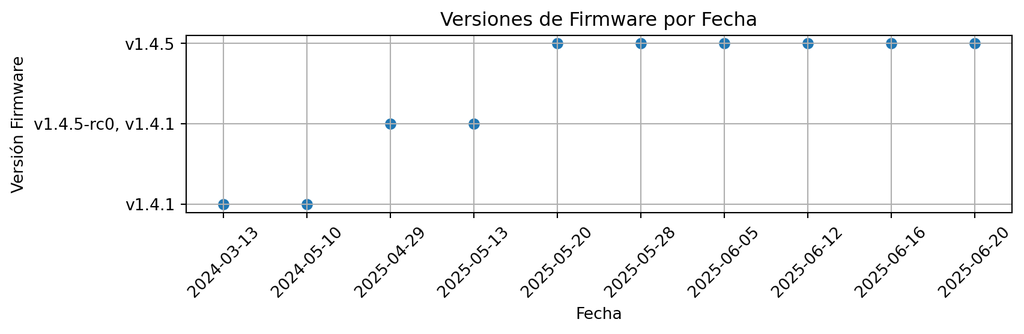

### 2.1.2 Bandas existentes vs Fecha

| Fecha | BandName |
| --- | --- |
| 2024-03-13 | ['NIR' 'Red edge' 'Blue' 'Green' 'Red'] |
| 2024-05-10 | ['NIR' 'Red edge' 'Blue' 'Green' 'Red'] |
| 2025-04-29 | ['Blue-444' 'Green-531' 'Red edge-740' 'Red-650' 'Red edge-705' 'PanchroB' 'Blue' 'Green' 'Red' 'NIR' 'Red edge' 'Panchro'] |
| 2025-05-13 | ['Blue-444' 'Green-531' 'Red edge-740' 'Red-650' 'Red edge-705' 'PanchroB' 'Blue' 'Green' 'Red' 'NIR' 'Red edge' 'Panchro'] |
| 2025-05-20 | ['Blue' 'Red-650' 'Red edge-705' 'Green' 'Red' 'NIR' 'Red edge' 'Panchro' 'Blue-444' 'Green-531' 'Red edge-740'] |
| 2025-05-28 | ['Blue' 'Red-650' 'Red edge-705' 'Green' 'Red' 'NIR' 'Red edge' 'Panchro' 'Blue-444' 'Green-531' 'Red edge-740'] |
| 2025-06-05 | ['Blue' 'Red-650' 'Red edge-705' 'Green' 'Red' 'NIR' 'Red edge' 'Panchro' 'Blue-444' 'Green-531' 'Red edge-740'] |
| 2025-06-12 | ['Blue' 'Red-650' 'Red edge-705' 'Green' 'Red' 'NIR' 'Red edge' 'Panchro' 'Blue-444' 'Green-531' 'Red edge-740'] |
| 2025-06-16 | ['Blue' 'Red-650' 'Red edge-705' 'Green' 'Red' 'NIR' 'Red edge' 'Panchro' 'Blue-444' 'Green-531' 'Red edge-740'] |
| 2025-06-20 | ['Blue' 'Red-650' 'Red edge-705' 'Green' 'Red' 'NIR' 'Red edge' 'Panchro' 'Blue-444' 'Green-531' 'Red edge-740'] |

- Se evidencia que en las dos primeras fechas $2024-03-13$ y $2024-05-10$ solo existen 5 bandas con información. La banda faltante aparece como una imagen vacía.
- Luego del envío de la cámara a Estados Unidos, se produjo la captura en las fechas $2025-04-29$ y $2025-05-13$, donde se reportaban 6 bandas por cámara, debido a que se habían colocado firmwares distintos en cada una de ellas (RED - v1.4.5-rc0 y BLUE - v1.4.1, respectivamente).
- A partir de la última captura se detectó la discrepancia de firmwares y se actualizaron ambas cámaras a la versión 1.4.5. Con ello, las dos últimas fechas del primer experimento de palmeri ($2025-05-20$, $2025-05-28$) y las cuatro fechas completas del segundo experimento ($2025-06-05$, $2025-06-12$, $2025-06-16$ , $2025-06-20$) tienen 6 bandas en la cámara RED y 5 bandas en la cámara BLUE, respectivamente. Esta última configuración cumple con el funcionamiento indicado por el fabricante sobre el número de bandas en configuración dual, pero se mantiene la discrepancia respecto del orden de las bandas.

### 2.1.3 Bandas vs. Posición en la cámara (CameraRigIndex - EXIF)

Se ha buscado relación posible de la discrepancia con la información EXIF del RigIndex, pero se encontró que debido a las distintas versiones de firmwares presentes en cada captura, este dato no es constante en el tiempo.

| BandName | RigCameraIndex |
| --- | --- |
| Blue | [6 0] |
| Blue-444 | [0 6] |
| Green | [7 1] |
| Green-531 | [1 7] |
| NIR | [9 3] |
| Panchro | [5] |
| PanchroB | [5] |
| Red | [8 2] |
| Red edge | [10 4] |
| Red edge-705 | [ 4 10] |
| Red edge-740 | [2 8] |
| Red-650 | [3 9] |